# Exploratory_data_analysis_Montreal_properties

## Exploratory Data Analysis for the Residential Property Listings in the City of Montreal (Canada).

Import the required packages.

```python
import os
import time
import numpy as np
import pandas as pd
import seaborn as sns
from datetime import date
import matplotlib.pyplot as plt
```

Start the clock for the code execution time.

```python
t0 = time.time()
```

Load the dataset and add a new column named **pricem** depicting house price in the units of million dollars.

```python
path = os.getcwd()+"/clean_Montreal_property_listings.xlsx"
data = pd.read_excel(path)
data = data.loc[data.bedrooms < 5]
data['pricem'] = data['price']/1000000
data.head()
```

|  | price | region | address | bedrooms | pricem |
| --- | --- | --- | --- | --- | --- |
| 0 | 849000.0 | Mercier / Hochelaga / Maisonneuve | 5185-5187 RUE DESMARTEAU | 3 | 0.849 |
| 1 | 420000.0 | Villeray / St-Michel / Parc-Extension | 417-8635 RUE LAJEUNESSE | 2 | 0.420 |
| 2 | 699000.0 | Pointe-Aux-Trembles / Montréal-Est | 11901 Victoria | 3 | 0.699 |
| 3 | 349000.0 | Rosemont / La Petite Patrie | 5919 rue Chabot | 1 | 0.349 |
| 4 | 959000.0 | Ahuntsic / Cartierville | 2143 boulevard Gouin Est | 4 | 0.959 |

Check the missing values.

```python
data.isna().sum()
```

```
price       2
region      0
address     0
bedrooms    0
pricem      2
dtype: int64
```

There are two NaN values in the **price** column.

Remove the NaN values.

```python
data.dropna(inplace= True)
```

```python
print('The dataset has a total of', data.shape[0], 'rows and', data.shape[1], 'columns.')
```

```
The dataset has a total of 731 rows and 5 columns.
```

Check the distribution of property prices.

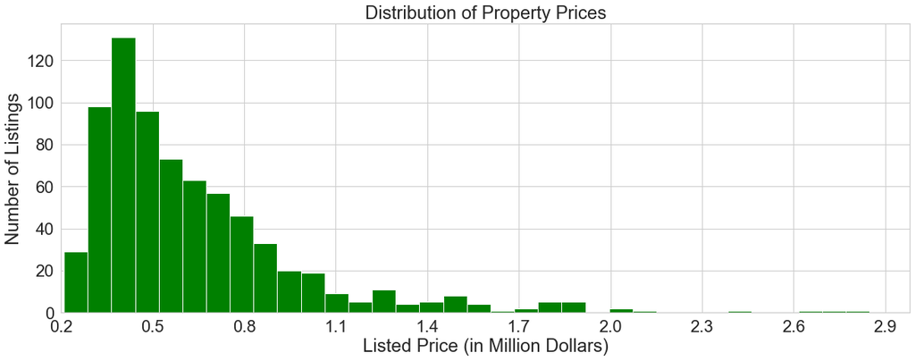

```python
sns.set(font_scale= 2)
sns.set_style('whitegrid')
plt.figure(figsize= (20,7))
plt.title('Distribution of Property Prices')
sns.distplot(data.pricem, kde = False, color = 'green', hist_kws=dict(alpha=1))
plt.xlabel('Listed Price (in Million Dollars)')
plt.ylabel('Number of Listings')
plt.xticks(np.arange(0.2, 3.0, 0.3))
plt.xlim(0.2, );
```

Above figure shows that majority of the residential property prices in Montreal lie in a range between 0.2-1.0 million dollars.

Another nice way to visualize the distribution of property prices is using violin plot overlapped with the swarm plot, as shown below.

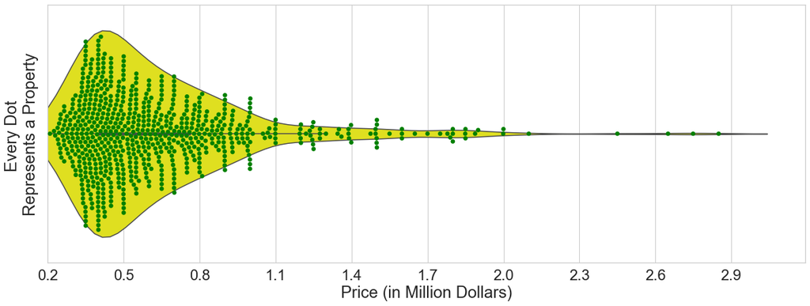

```python
sns.set(font_scale=2)
sns.set_style('whitegrid')
plt.figure(figsize= (20,7))
sns.violinplot(data.pricem, color= 'yellow')
sns.swarmplot(data.pricem, color= 'green', alpha = 1, size= 6.5)
plt.xlabel('Price (in Million Dollars)')
plt.ylabel('Every Dot \nRepresents a Property')
plt.xlim(0.2, )
plt.xticks(np.arange(0.2, 3.0, 0.3));
```

Number of listings in each region.

```python
data_region_lisitngs = (((data.groupby(by = 'region').count()).reset_index()).drop(columns= ['address', 'bedrooms', 'pricem']))
data_region_lisitngs.rename(columns= {'price' : 'count'}, inplace= True)
data_region_lisitngs.sort_values(by= 'count', ascending= False).reset_index().drop(columns= 'index').head()
```

|  | region | count |
| --- | --- | --- |
| 0 | Ville-Marie (Centre-Ville et Vieux Mtl) | 140 |
| 1 | Mercier / Hochelaga / Maisonneuve | 73 |
| 2 | Ahuntsic / Cartierville | 55 |
| 3 | Rosemont / La Petite Patrie | 50 |
| 4 | Le Plateau-Mont-Royal | 46 |

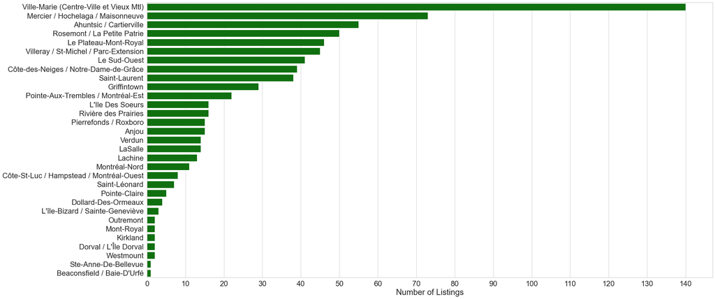

```python
order = data_region_lisitngs.sort_values(by = 'count', ascending= False).region
sns.set(font_scale=2)
sns.set_style('whitegrid')
plt.figure(figsize= (30,15))
sns.barplot(data= data_region_lisitngs, y = 'region', x = 'count', order = order, color= 'green')
plt.xlabel('Number of Listings')
plt.ylabel('')
plt.xticks(np.arange(0, 150, 10));
```

It will be interesting to see the distribution of number of properties in terms of the number of bedrooms the property contains.

Below shown is the number of property lisitngs in the dataset for a given number of bedrooms.

```python
data_gr_bedrooms = ((data.groupby(by= 'bedrooms').count())[['price']])
data_gr_bedrooms.reset_index(inplace= True)
data_gr_bedrooms.rename(columns= {'price' : 'count'}, inplace= True)
data_gr_bedrooms
```

|  | bedrooms | count |
| --- | --- | --- |
| 0 | 1 | 193 |
| 1 | 2 | 271 |
| 2 | 3 | 185 |
| 3 | 4 | 82 |

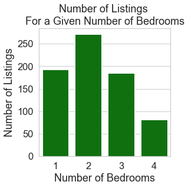

```python
sns.set(font_scale=1.5)
sns.set_style('whitegrid')
plt.figure(figsize= (4,4))
sns.barplot(data = data_gr_bedrooms, x = 'bedrooms', y ='count', color = 'green', alpha = 1)
plt.xlabel('Number of Bedrooms')
plt.ylabel('Number of Listings')
plt.title('Number of Listings \nFor a Given Number of Bedrooms');
```

Above barplot indicates that one, two and three bedroom properties are present the most.

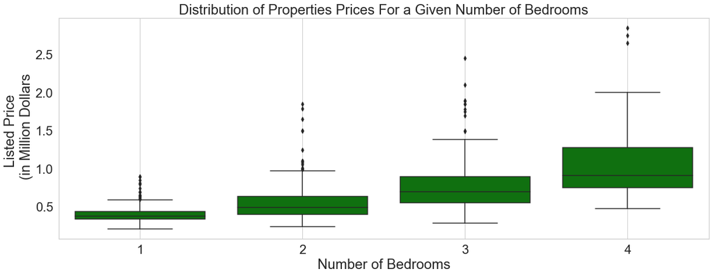

```python
sns.set(font_scale= 2)
sns.set_style('whitegrid')
plt.figure(figsize= (20,7))
sns.boxplot(y = data.pricem, x = data.bedrooms ,color = 'green', boxprops=dict(alpha=1))
plt.grid()
plt.xlabel('Number of Bedrooms')
plt.ylabel('Listed Price \n (in Million Dollars')
plt.title('Distribution of Properties Prices For a Given Number of Bedrooms');
```

The horizontal line black inside the boxes in above boxplot depicts the median price of the listed properties. From the above figure, we observe that the median price of the property increases with the number of bedrooms a property contains.

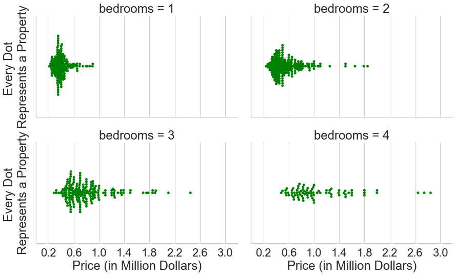

```python
sns.set(font_scale=2)
sns.set_style('whitegrid')
g = sns.FacetGrid(data, col = 'bedrooms', col_wrap= 2, height= 4, aspect= 1.5)
#g.map(sns.violinplot, 'pricem', color = 'yellow', order = None)
g.map(sns.swarmplot, 'pricem', color = 'green', order = None)
g.set_xlabels('Price (in Million Dollars)');
g.set_ylabels('Every Dot \nRepresents a Property');
g.set(xlim = (0, 3.2), xticks = (np.arange(0.2, 3.4, 0.4)))
```

Above swarm plot also confirms that the property price increases with the number of bedrooms.

Apart from the number of bedrooms, the property prices can also vary within different regions of the city.

Below we see how many distinct regions are present in dataset.

```python
data_gr_region  = data['region'].unique()
data_gr_region = (pd.DataFrame({'Region' : data_gr_region}).sort_values(by = 'Region').reset_index()).drop(columns= ['index'])
data_gr_region
```

|  | Region |
| --- | --- |
| 0 | Ahuntsic / Cartierville |
| 1 | Anjou |
| 2 | Beaconsfield / Baie-D'Urfé |
| 3 | Côte-St-Luc / Hampstead / Montréal-Ouest |
| 4 | Côte-des-Neiges / Notre-Dame-de-Grâce |
| 5 | Dollard-Des-Ormeaux |
| 6 | Dorval / L'Île Dorval |
| 7 | Griffintown |
| 8 | Kirkland |
| 9 | L'Ile Des Soeurs |
| 10 | L'île-Bizard / Sainte-Geneviève |
| 11 | LaSalle |
| 12 | Lachine |
| 13 | Le Plateau-Mont-Royal |
| 14 | Le Sud-Ouest |
| 15 | Mercier / Hochelaga / Maisonneuve |
| 16 | Mont-Royal |
| 17 | Montréal-Nord |
| 18 | Outremont |
| 19 | Pierrefonds / Roxboro |
| 20 | Pointe-Aux-Trembles / Montréal-Est |
| 21 | Pointe-Claire |
| 22 | Rivière des Prairies |
| 23 | Rosemont / La Petite Patrie |
| 24 | Saint-Laurent |
| 25 | Saint-Léonard |
| 26 | Ste-Anne-De-Bellevue |
| 27 | Verdun |
| 28 | Ville-Marie (Centre-Ville et Vieux Mtl) |
| 29 | Villeray / St-Michel / Parc-Extension |
| 30 | Westmount |

```python
print('There are a total of', data_gr_region.shape[0], 'distinct regions in the city of Montreal.')
```

```
There are a total of 31 distinct regions in the city of Montreal.
```

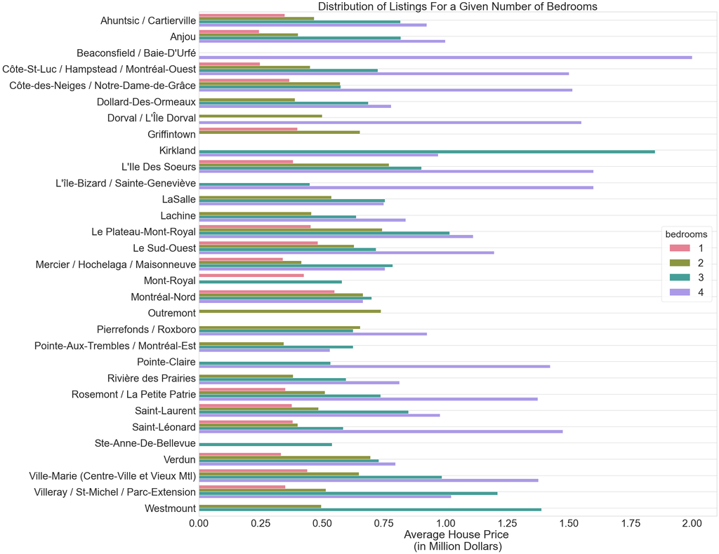

```python
data_new = data.groupby(by = ['bedrooms', 'region']).mean()
data_new.reset_index(inplace= True)

sns.set(font_scale=3)
sns.set_style('whitegrid')
plt.figure(figsize= (30,30))
order = sorted(data.region.unique().tolist())
sns.barplot(x = data_new.price/1000000, y = data_new.region, palette="husl", hue= data_new.bedrooms, order = order)
plt.grid()
plt.xlabel('Average House Price \n(in Million Dollars)')
plt.ylabel('')
plt.title('Distribution of Listings For a Given Number of Bedrooms');
```

Check the variation in the listed property prices in different regions of Montreal.

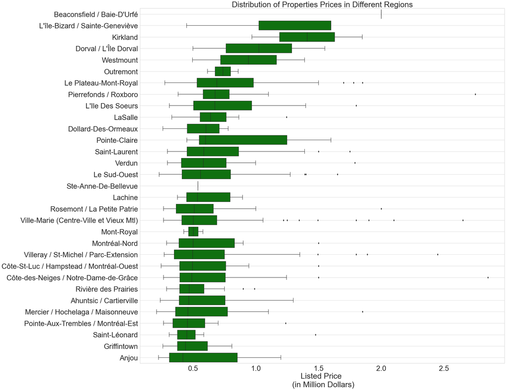

```python
sns.set(font_scale = 3)
sns.set_style('whitegrid')
plt.figure(figsize= (30,30))
order = data.groupby(["region"])["price"].median().sort_values(ascending= False).index
sns.boxplot(x = data.price/1000000, y = data.region ,color = 'green', order = order, boxprops=dict(alpha=1))
plt.grid()
plt.xlabel('Listed Price \n (in Million Dollars)')
plt.ylabel('')
plt.title('Distribution of Properties Prices in Different Regions');
```

The exploratory data analysis shows that both the number of bedrooms a property contains, as well as the region where a property is located are important factors in determinig the listed price of the property.

```python
print(date.today())
```

```
2022-03-15
```

```python
print('Total code runtime excluding time to load the packages is', time.time()-t0, 'seconds')
```

```
Total code runtime excluding time to load the packages is 3.4236669540405273 seconds
```

**Author:**

**Mangaljit Singh**